# Learning About Wine From Scratch

Oleksiy Anokhin

6/17/2019

**Introduction**

I do not know anything about wine. A man supposed to know something, I guess. How to chose good wine and what does “good” actually mean. I never cared about wine too much, even being born in a place, famous for its wines. Last Cristmas I just bought three bottles of Georgian wine, because I just expected it to be good + having some sympathy to local producers.

This time I decided to learn about wine in a more scientific way. I picked a dataset from [Kaggle](https://www.kaggle.com/zynicide/wine-reviews), which stores information about almost 130000 different wines, its price, rankings, origin etc.

This is how the dataset looks like. For me three the most interesting variables are: `country`, `points`, and `price`. These variables will allow me to make a quick analysis of wine quality and its price, taking into account its origin.

| country | description | designation | points | price | province | region_1 | region_2 | taster_name | taster_twitter_handle | title | variety | winery |
| --- | --- | --- | --- | --- | --- | --- | --- | --- | --- | --- | --- | --- |
| Italy | Aromas include tropical fruit, broom, brimstone and dried herb. The palate isn’t overly expressive, offering unripened apple, citrus and dried sage alongside brisk acidity. | Vulkà Bianco | 87 | NA | Sicily & Sardinia | Etna | NA | Kerin O’Keefe | @kerinokeefe | Nicosia 2013 Vulkà Bianco (Etna) | White Blend | Nicosia |

Unfortunately, there many `NA` (missing data) for some variables, which will make the analysis a little less accurate.

**Question 1. Visualize the correlation between price and ranking.**

Correlation always helpful to see the some basic patterns and outliers.

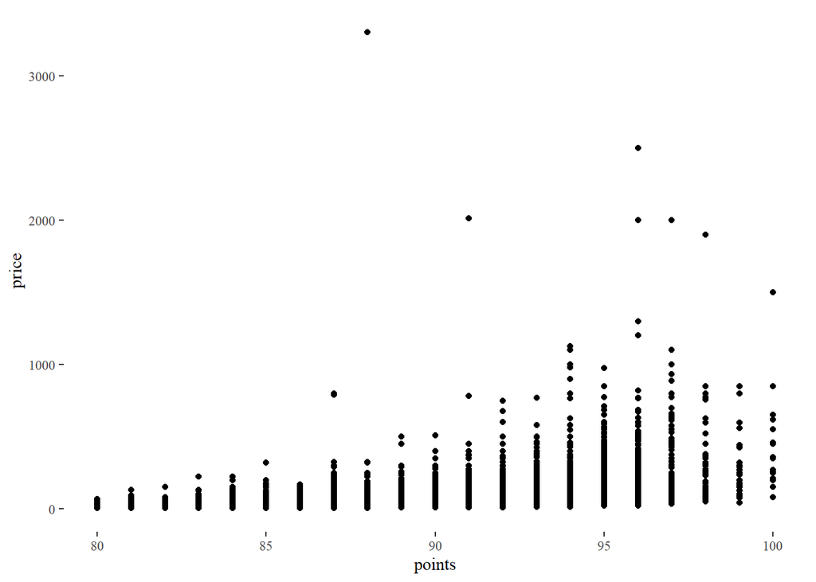

We can see our first chart, where different types of wine are visualized by price and points, assigned to each type of wine by experts.[^1] We definitely see some outliers on this graph. For example, we can see that several wines cost about 2000 dollars, but at the same time experts give them pretty the same score as much cheaper options. Moreover, one wine cost more than 3000 dollars and its score is below 90.

As a person, who does not know anything about wine, but tries to maximize my own utility, I am focused on several types of wine, which ar elocated in the bottom right corner and have the lowest price and the rest rankings. Actucally, it is a good idea to create a **ratio**, which will help to identify the best deals among almost 130000 options.

First of all, I decided to do some exploratory analysis of this dataset, trying to understand some “wine patterns”.

**2. How many countries are in our dataset? Which countries are presented most of all?**

If we summarize our data by country, we can see that US wine presents about 40% of the whole dataset. Besides, other traditional countries like France, Italy, Spain, Portugal, and Chile have their own solid represenation in this dataset. Moreover, I identified 14 different wines from Ukraine and I am willing to explore it separately.

| country | n() |
| --- | --- |
| US | 54504 |
| France | 22093 |
| Italy | 19540 |
| Spain | 6645 |
| Portugal | 5691 |
| Chile | 4472 |
| Argentina | 3800 |
| Austria | 3345 |
| Australia | 2329 |
| Germany | 2165 |
| New Zealand | 1419 |
| South Africa | 1401 |
| Israel | 505 |
| Greece | 466 |
| Canada | 257 |
| Hungary | 146 |
| Bulgaria | 141 |
| Romania | 120 |
| Uruguay | 109 |
| Turkey | 90 |
| Slovenia | 87 |
| Georgia | 86 |
| England | 74 |
| Croatia | 73 |
| Mexico | 70 |
| NA | 63 |
| Moldova | 59 |
| Brazil | 52 |
| Lebanon | 35 |
| Morocco | 28 |
| Peru | 16 |
| Ukraine | 14 |
| Czech Republic | 12 |
| Macedonia | 12 |
| Serbia | 12 |
| Cyprus | 11 |
| India | 9 |
| Switzerland | 7 |
| Luxembourg | 6 |
| Armenia | 2 |
| Bosnia and Herzegovina | 2 |
| China | 1 |
| Egypt | 1 |
| Slovakia | 1 |

I decided to analyze which wine has “the best value”, the ratio of the cost and points.

I just selected two parameters - points and price (and three other variables) and removed all NA values. As a result, I got 120,915 rows (total dataset was 129,971)

```
## # A tibble: 120,915 x 6
##    title                        country points price variety     wine_value
##    <chr>                        <chr>    <dbl> <dbl> <chr>            <dbl>
##  1 Bandit NV Merlot (Californi~ US          86     4 Merlot          0.0465
##  2 Cramele Recas 2011 UnWineD ~ Romania     86     4 Pinot Grig~     0.0465
##  3 Felix Solis 2013 Flirty Bir~ Spain       85     4 Syrah           0.0471
##  4 Dancing Coyote 2015 White (~ US          85     4 White Blend     0.0471
##  5 Broke Ass 2009 Red Malbec-S~ Argent~     84     4 Malbec-Syr~     0.0476
##  6 Bandit NV Chardonnay (Calif~ US          84     4 Chardonnay      0.0476
##  7 Terrenal 2010 Cabernet Sauv~ Spain       84     4 Cabernet S~     0.0476
##  8 Bandit NV Merlot (Californi~ US          84     4 Merlot          0.0476
##  9 Terrenal 2010 Estate Bottle~ Spain       84     4 Tempranillo     0.0476
## 10 Pam's Cuties NV Unoaked Cha~ US          83     4 Chardonnay      0.0482
## # ... with 120,905 more rows
```

Now you can see that some wines for only 4 bucks have high points.

Next I tried to see which countries with affordable prices have on average high poins. Here I did not select all countries, but only countries which have more than 1000 different types.

[^1]: Removed 8996 rows containing missing values.